# Estimating the Intrinsic Number of Orderings

## Question

Can MPCurve recover the number of latent sample orderings when the true number is three, four, or five? We compare **adaptive empirical Bayes (EB)** with **a fixed uniform ordering prior and forward selection**, using the same simulated datasets for both methods.

## Simulation design

Each dataset has **300 samples and 60 features**. Features belong to equally sized groups following **3, 4, or 5 independent orderings**, giving 20, 15, or 12 features per ordering. For sample $i$ and feature $j$,

$$X_{ij}=f_j(t_{i,z_j})+\epsilon_{ij},$$

where $z_j$ identifies the generating ordering, latent positions are independent Uniform$(0,1)$ draws, and $f_j$ is a smooth monotone curve. Each curve is a random weighted combination of monotone basis functions, with its direction chosen to be increasing or decreasing. Under the parameters used here, most resulting trajectories have mild curvature and are close to linear. Each noiseless feature is centered and scaled to sample variance one before independent Gaussian noise is added.

The variance signal-to-noise ratio is **1, 4, or 16**, corresponding to noise standard deviations of 1, 0.5, or 0.25. There are **10 independent datasets for each of the nine conditions**, or **90 datasets in total**. Separate pilot datasets were used to check the implementation and runtime; they are excluded from these results.

### Simulated trajectories and observations

The figures below show **replicate 1 from every condition**. Each row is a true ordering and each column is an SNR setting. For the first three features in each group, solid lines show the noiseless signal and points show all 300 noisy observations, plotted against that group’s true latent positions. All panels use the same axis scales. Conditions use independent datasets, so both the generating curves and noise realizations differ across columns.

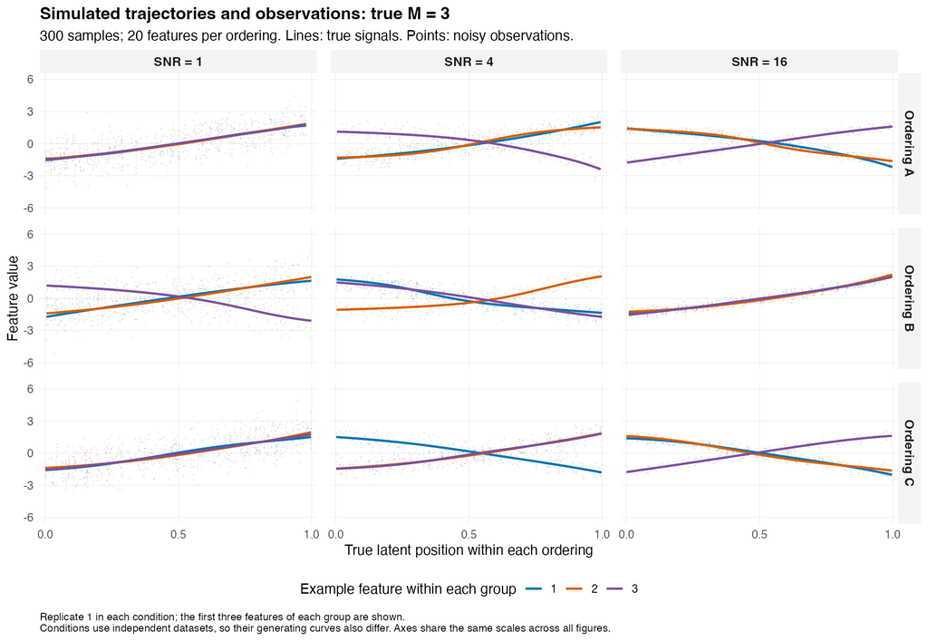

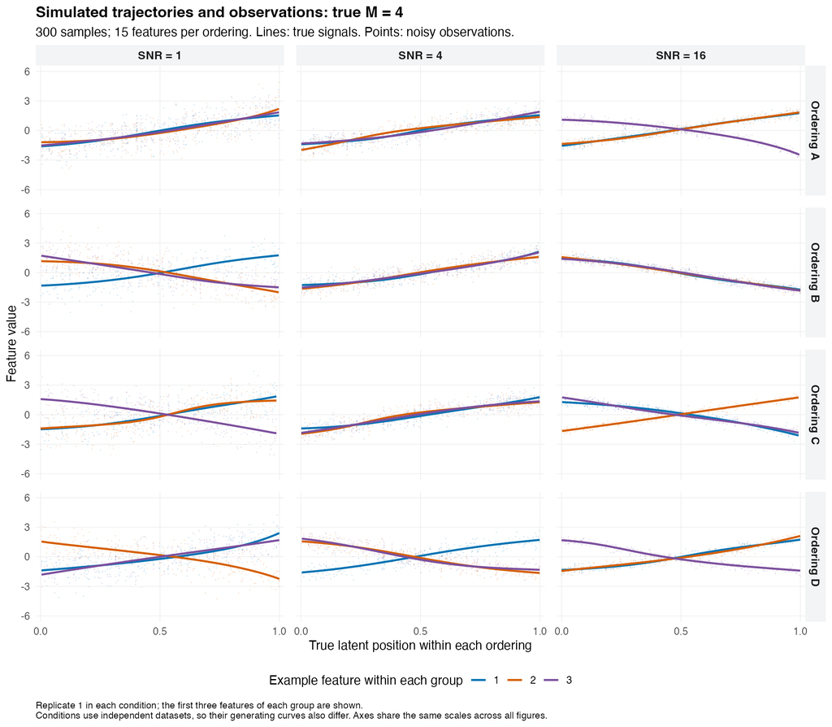

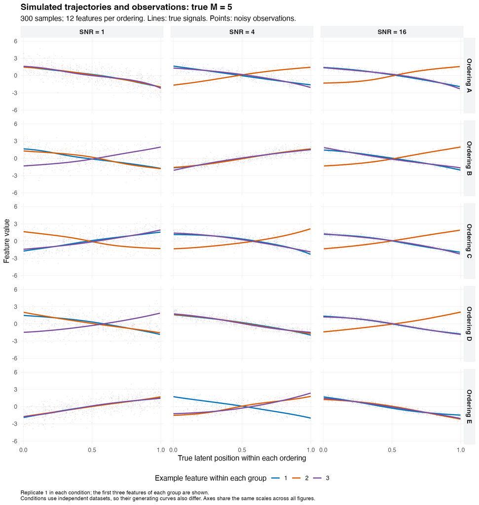

## Methods

Both methods use MPCurver **0.3.2**, CAVI, **50 grid positions**, a second-order random-walk prior with `ridge = 0`, adaptive cell-position priors, and estimated feature-specific noise and smoothness. Initialization clusters features using absolute Spearman correlation and single linkage, then uses Isomap within each group. A singleton group is initialized by ranking its feature.

- **Adaptive EB:** fit eight candidate orderings with adaptive ordering-assignment weights.
- **Uniform + forward:** fix the ordering prior to $1/M$, start at $M=1$, and fit successively larger $M$, up to eight. Accept a candidate only when its converged, soft-assignment ELBO at temperature one exceeds the preceding candidate’s score. Stop at the first non-improvement.

For both methods, the estimated **effective M** counts orderings whose mean posterior feature-assignment probability exceeds $10^{-12}$. Unused ordering slots are excluded. For adaptive EB, these mean probabilities equal the fitted assignment-prior weights.

Each candidate has one initialization. Partition fits use a temperature schedule from five to one, followed by refinement at temperature one. Fitting stops when the absolute ELBO change divided by $N D$ is below $10^{-6}$, subject to the algorithm’s numerical nondecrease check and completion of annealing. Continuation preserves the current fit. Candidates that remain unconverged after the declared 10,000-sweep limit are recorded as unresolved, including forward searches whose next comparison cannot be completed.

## Recovery of M

Exact recovery, underestimation, overestimation, and unresolved outcomes use all 10 planned repeats as their denominator. Error bars are 95% Wilson intervals. The methods are assessed against the generating truth; their ELBO values are not compared against each other.

Adaptive EB recovers the true effective M in **87 of 90 datasets**; uniform + forward does so in **90 of 90 datasets**.

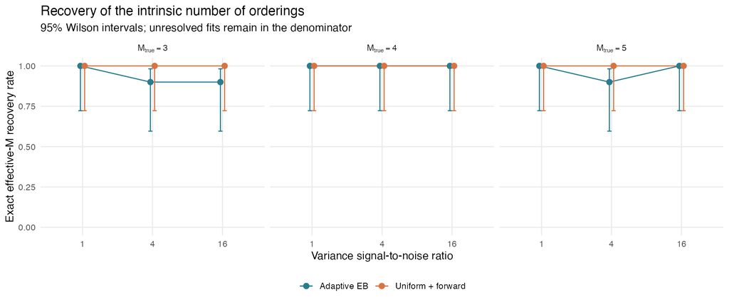

Counts out of 10 datasets per condition and method.

| True M | SNR | Method | Exact | Under | Over | Unresolved |
| --- | --- | --- | --- | --- | --- | --- |
| 3 | 1 | Adaptive EB | 10 | 0 | 0 | 0 |
| 4 | 1 | Adaptive EB | 10 | 0 | 0 | 0 |
| 5 | 1 | Adaptive EB | 10 | 0 | 0 | 0 |
| 3 | 4 | Adaptive EB | 9 | 0 | 1 | 0 |
| 4 | 4 | Adaptive EB | 10 | 0 | 0 | 0 |
| 5 | 4 | Adaptive EB | 9 | 0 | 1 | 0 |
| 3 | 16 | Adaptive EB | 9 | 0 | 1 | 0 |
| 4 | 16 | Adaptive EB | 10 | 0 | 0 | 0 |
| 5 | 16 | Adaptive EB | 10 | 0 | 0 | 0 |
| 3 | 1 | Uniform + forward | 10 | 0 | 0 | 0 |
| 4 | 1 | Uniform + forward | 10 | 0 | 0 | 0 |
| 5 | 1 | Uniform + forward | 10 | 0 | 0 | 0 |
| 3 | 4 | Uniform + forward | 10 | 0 | 0 | 0 |
| 4 | 4 | Uniform + forward | 10 | 0 | 0 | 0 |
| 5 | 4 | Uniform + forward | 10 | 0 | 0 | 0 |
| 3 | 16 | Uniform + forward | 10 | 0 | 0 | 0 |
| 4 | 16 | Uniform + forward | 10 | 0 | 0 | 0 |
| 5 | 16 | Uniform + forward | 10 | 0 | 0 | 0 |

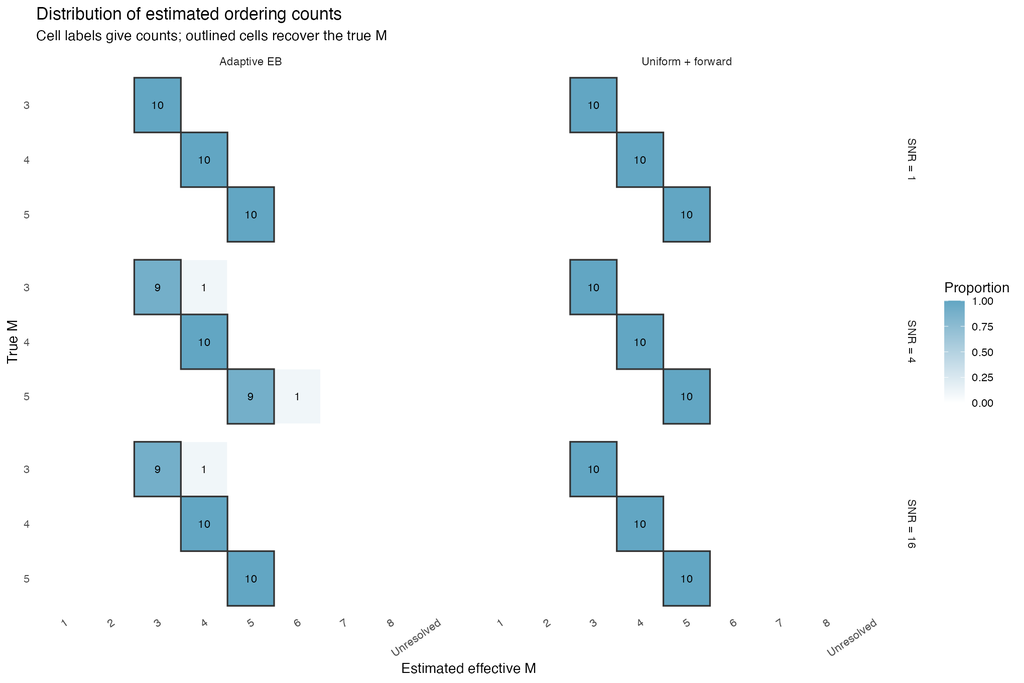

## Recovery of the underlying structure

Feature-group recovery is measured by the adjusted Rand index (ARI), assigning each feature to the ordering with the largest posterior assignment probability. An ordering with no assigned features does not change this partition.

For ordering recovery, inferred positions are matched one-to-one to the true orderings by absolute Spearman correlation, allowing reversal of an axis. Unmatched true orderings contribute zero to the mean recovery score. These structural summaries describe completed fits; unresolved rates are reported separately above.

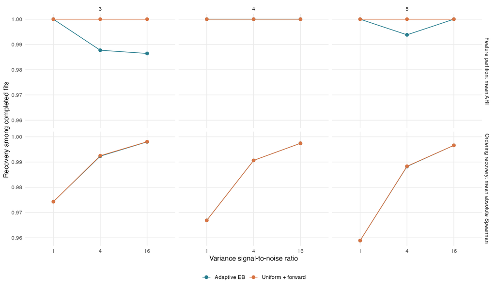

### Examples with true M = 3, 4, and 5

These examples were fixed in advance: replicate 1 at SNR 4 for each true dimension. The first row shows three generating curves per ordering; the following rows compare true and inferred sample positions.

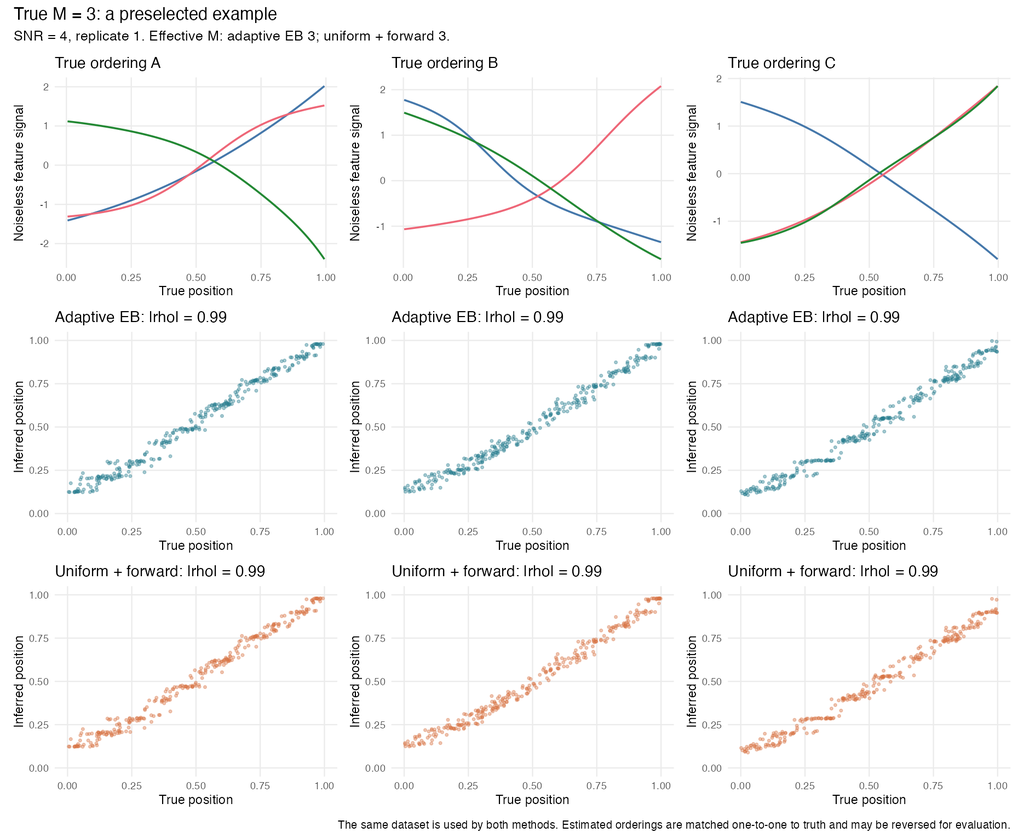

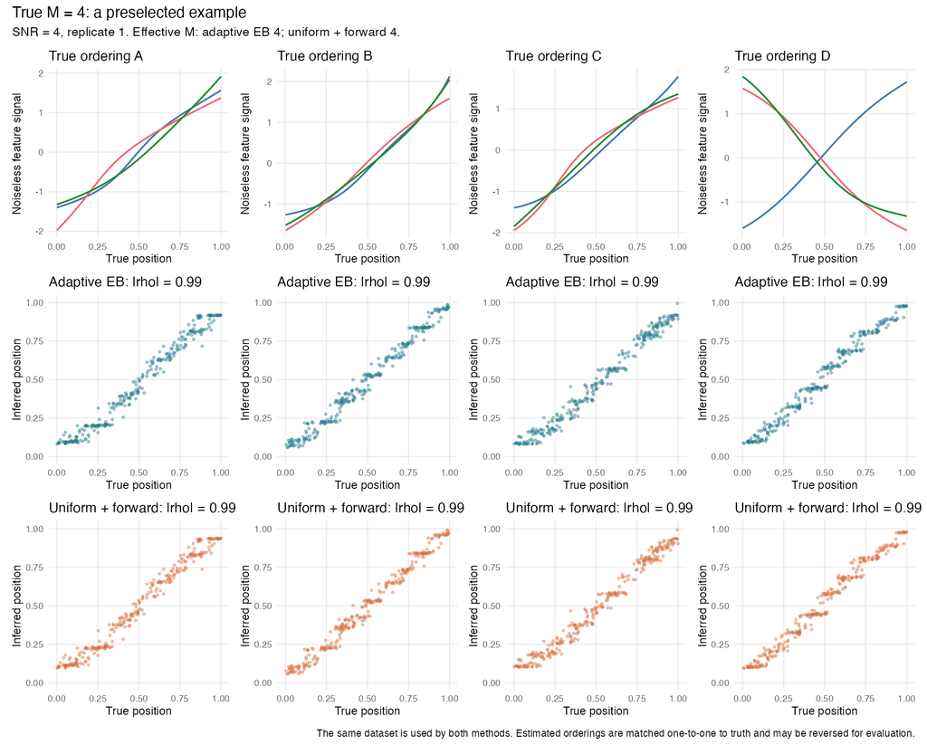

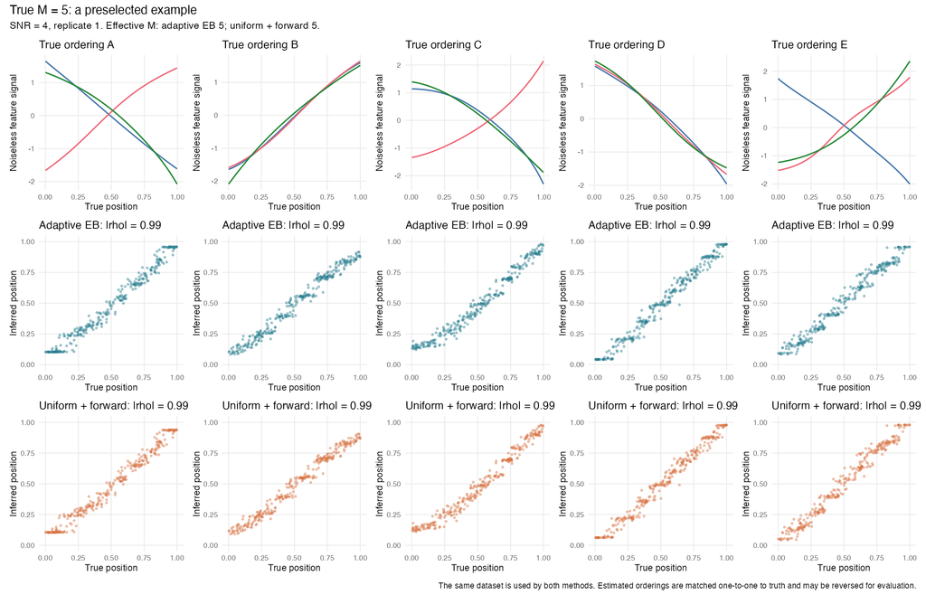

## Runtime and convergence

Runtime includes initialization and every candidate and continuation used by each method. A forward search therefore includes its rejected stopping candidate. All workers use one CPU thread.

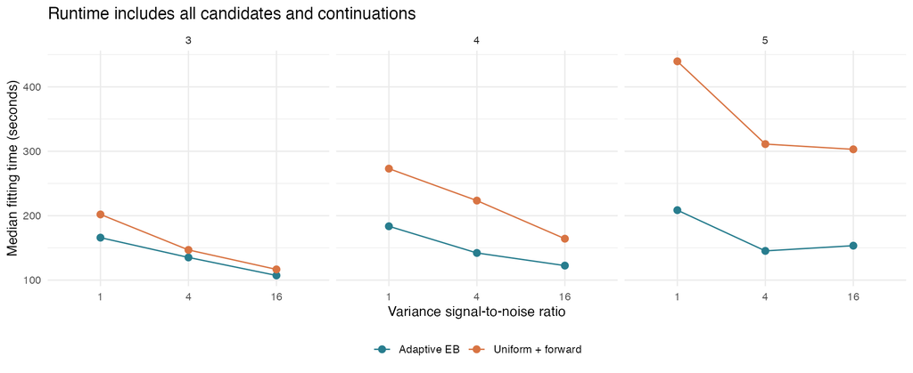

The study completed **180 of 180 method runs** with a converged estimate. The remaining **0** runs are included as unresolved outcomes in the main recovery rates.

## Summary and reproduction

Both approaches recover the effective number of orderings well in this benchmark of balanced feature groups, independent orderings, and mostly mildly curved monotone trajectories. Uniform-prior greedy forward selection has slightly higher recovery in these simulations: **90/90**, compared with **87/90** for adaptive EB. The three EB errors each add one effective ordering.

The [experiment directory](https://github.com/AgueroZZ/InferOrder/tree/master/experiments/estimate_intrinsic_m_v032) contains the fixed design and seeds, scripts, summaries, and standalone report source. Each dataset is shared by the two methods, and saved candidates support continuation and reproducibility.